# Analysis of U.S. Storm Damage Loss

Chen Xing

3/23/2022

## Abstract

In this analysis, we use the *“Storm Data”* from NOAA to count which event resulted in the greatest economic loss and loss of life from 1950 to 2011. The methodology of the statistics includes classification according to different types of events and calculation of totals and averages. The results show that tornado is the greatest threat to life and health, Tsunami is the most dangerous event, the flood caused the greatest total economic damage and The storm surge/tide is the single most economically costly event type.

## Data Processing

### 1. Load Packages

The R package `Tidyverse` is main tool in this analysis.

```r
require(tidyverse)
require(lubridate)
require(ggpubr)
```

### 2. Load the data

Thanks to the use of tidyverse, we can directly load the data downloaded from assignment website without unzipping it.  
And we can load event name list information from “Storm Data Documentation” pdf file.

```r
dt <- read_csv("repdata-data-StormData.csv.bz2")
eventlist <- read_csv("even_list.csv") %>% mutate(EVTYPE=toupper(EVTYPE))
```

### 3. Select the Data

We select the data we need to find the answers to these two questions, and group the data by severe weather types.

```r
dt_1 <- dt %>% select(BGN_DATE, BGN_TIME, EVTYPE, FATALITIES, INJURIES, PROPDMG, PROPDMGEXP,CROPDMG, CROPDMGEXP) %>% mutate(EVTYPE=toupper(EVTYPE)) %>%
  filter(EVTYPE %in% eventlist$EVTYPE) %>%
  mutate(BGN_DATE=mdy_hms(BGN_DATE)) %>%
  group_by(EVTYPE)

head(dt_1)
```

```
## # A tibble: 6 × 9
## # Groups:   EVTYPE [1]
##   BGN_DATE            BGN_TIME EVTYPE  FATALITIES INJURIES PROPDMG PROPDMGEXP
##   <dttm>              <chr>    <chr>        <dbl>    <dbl>   <dbl> <chr>
## 1 1950-04-18 00:00:00 0130     TORNADO          0       15    25   K
## 2 1950-04-18 00:00:00 0145     TORNADO          0        0     2.5 K
## 3 1951-02-20 00:00:00 1600     TORNADO          0        2    25   K
## 4 1951-06-08 00:00:00 0900     TORNADO          0        2     2.5 K
## 5 1951-11-15 00:00:00 1500     TORNADO          0        2     2.5 K
## 6 1951-11-15 00:00:00 2000     TORNADO          0        6     2.5 K
## # … with 2 more variables: CROPDMG <dbl>, CROPDMGEXP <chr>
```

### 4. Casualty Statistics

Calculate the total and average number of fatalities and injuries between `evtype`.

```r
dt_fj <- dt_1 %>% mutate(fj=FATALITIES+INJURIES) %>%
  summarise(sumfj=sum(fj), meanfj=mean(fj,na.rm=T),sumi=sum(INJURIES), meani=mean(INJURIES,na.rm=T),
            sumf=sum(FATALITIES), meanf=mean(FATALITIES, na.rm=T)) %>%
  arrange(-sumfj)

head(dt_fj)
```

```
## # A tibble: 6 × 7
##   EVTYPE         sumfj meanfj  sumi  meani  sumf  meanf
##   <chr>          <dbl>  <dbl> <dbl>  <dbl> <dbl>  <dbl>
## 1 TORNADO        96979 1.60   91346 1.51    5633 0.0929
## 2 EXCESSIVE HEAT  8428 5.02    6525 3.89    1903 1.13
## 3 FLOOD           7259 0.287   6789 0.268    470 0.0186
## 4 LIGHTNING       6046 0.384   5230 0.332    816 0.0518
## 5 HEAT            3037 3.96    2100 2.74     937 1.22
## 6 FLASH FLOOD     2755 0.0508  1777 0.0327   978 0.0180
```

### 5. Economic loss

Calculate the total and average economic consequences between `evtype`.

```r
dt_eco <- dt_1 %>% rowwise() %>%
  mutate_at(c("PROPDMGEXP","CROPDMGEXP"), ~ if (is.na(.x)) {1}
                             else if(.x=="K"){1000}else if(.x=="M"){1000000
                               }else if(.x=="B"){1000000000}else 1) %>%
  mutate(DMG_ALL=PROPDMG*PROPDMGEXP+CROPDMG*CROPDMGEXP) %>%
  ungroup() %>% group_by(EVTYPE) %>%
  summarise(sum_ecodmg=sum(DMG_ALL), mean_ecodmg=mean(DMG_ALL,na.rm=T)) %>%
  arrange(-sum_ecodmg)

head(dt_eco)
```

```
## # A tibble: 6 × 3
##   EVTYPE         sum_ecodmg mean_ecodmg
##   <chr>               <dbl>       <dbl>
## 1 FLOOD       150319678257     5935155.
## 2 TORNADO      57340614060.     945404.
## 3 HAIL         18752904943.      64965.
## 4 FLASH FLOOD  17562179167.     323560.
## 5 DROUGHT      15018672000     6036444.
## 6 ICE STORM     8967041360     4470110.
```

### 6. Merge Data

```r
dt_tidy <- left_join(dt_fj, dt_eco)
```

## Results

### 1. Across the United States, which types of events (as indicated in the `EVTYPE` variable) are most **harmful** with respect to population **health**?

#### Figure

Here we make a figure contain 4 plot include:  
- A: Total Casualty  
- B: Average Casualty  
- C: Total Fatality  
- D: Average Fatality

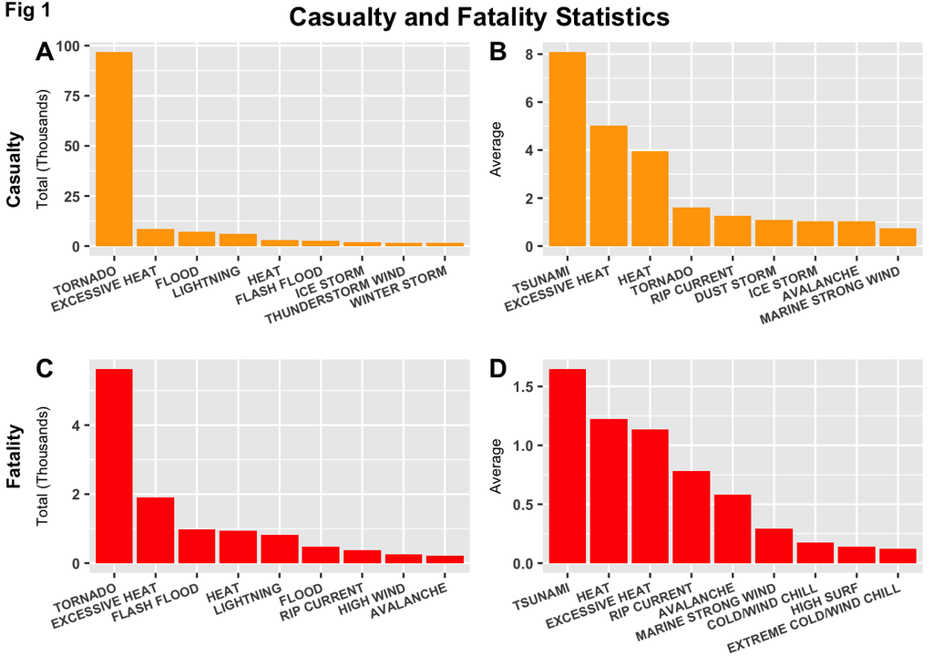

```r
# Calculate the 80% percentile for each variable.
quan <- dt_tidy %>% summarise(across(where(is.numeric),~ quantile(.x,0.8)))

# Plot A
p_sfj <- filter(dt_tidy, sumfj>quan$sumfj) %>%
  mutate(EVTYPE = fct_reorder(EVTYPE, -sumfj)) %>%
  ggplot(aes(EVTYPE,sumfj/1000)) + geom_col(fill="orange") +
  theme(axis.text.x = element_text(angle = 20, hjust = 1, vjust = 1, size=7,face="bold"),
        axis.text.y = element_text(size=8,face="bold"),
        axis.title.y = element_text(size = 8)) +
  labs(x = NULL, y = "Total (Thousands)")

# Plot B
p_mfj <- filter(dt_tidy, meanfj>quan$meanfj) %>%
  mutate(EVTYPE = fct_reorder(EVTYPE, -meanfj)) %>%
  ggplot(aes(EVTYPE,meanfj)) + geom_col(fill="orange") +
  theme(axis.text.x = element_text(angle = 20, hjust = 1, vjust = 1, size=7,face="bold"),
        axis.text.y = element_text(size=8,face="bold"),
        axis.title.y = element_text(size = 8)) +
  labs(x = NULL, y = "Average")

# Plot C
p_sf <- filter(dt_tidy, sumf>quan$sumf) %>%
  mutate(EVTYPE = fct_reorder(EVTYPE, -sumf)) %>%
  ggplot(aes(EVTYPE,sumf/1000)) + geom_col(fill="red") +
  labs(x = NULL, y = "Total (Thousands)") +
  theme(axis.text.x = element_text(angle = 20, hjust = 1, vjust = 1, size=7,face="bold"),
        axis.text.y = element_text(size=8,face="bold"),
        axis.title.y = element_text(size = 8))

# Plot D
p_mf <- filter(dt_tidy, meanf>quan$meanf) %>%
  mutate(EVTYPE = fct_reorder(EVTYPE, -meanf)) %>%
  ggplot(aes(EVTYPE,meanf)) + geom_col(fill="red") +
  theme(axis.text.x = element_text(angle = 20, hjust = 1, vjust = 1, size=7,face="bold"),
        axis.text.y = element_text(size=8,face="bold"),
        axis.title.y = element_text(size = 8)) +
  labs(x = NULL, y = "Average",title = waiver())

# Figure 1
fg1 <- ggarrange(p_sfj, p_mfj,p_sf, p_mf,labels = c("A", "B", "C", "D"), ncol = 2, nrow = 2, align="hv")
fg1 <- annotate_figure(fg1, top = text_grob("Casualty and Fatality Statistics", face = "bold", size = 14), left = text_grob("         Fatality                                          Casualty", face = "bold", size = 10, rot = 90), fig.lab = "Fig 1",fig.lab.face= "bold")
fg1
```

#### Discussion

**1. Tornado pose the greatest threat to life and health**  
In terms of total data(Fig1 A and C), tornadoes topped the list in terms of the number of casualties as well as the number of fatalities. Therefore, it is the largest in terms of total impact in terms of population health.  
**2. Tsunami is the most dangerous event**  
In terms of average data(Fig1 B and D), tsunami showed its extreme danger in casualties and fatalities. In addition to tsunamis, heat and excessive heat have shown their dangers and warrant vigilance in the face of a single event.

### 1. Across the United States, which types of events have the greatest **economic consequences**?

#### Figure

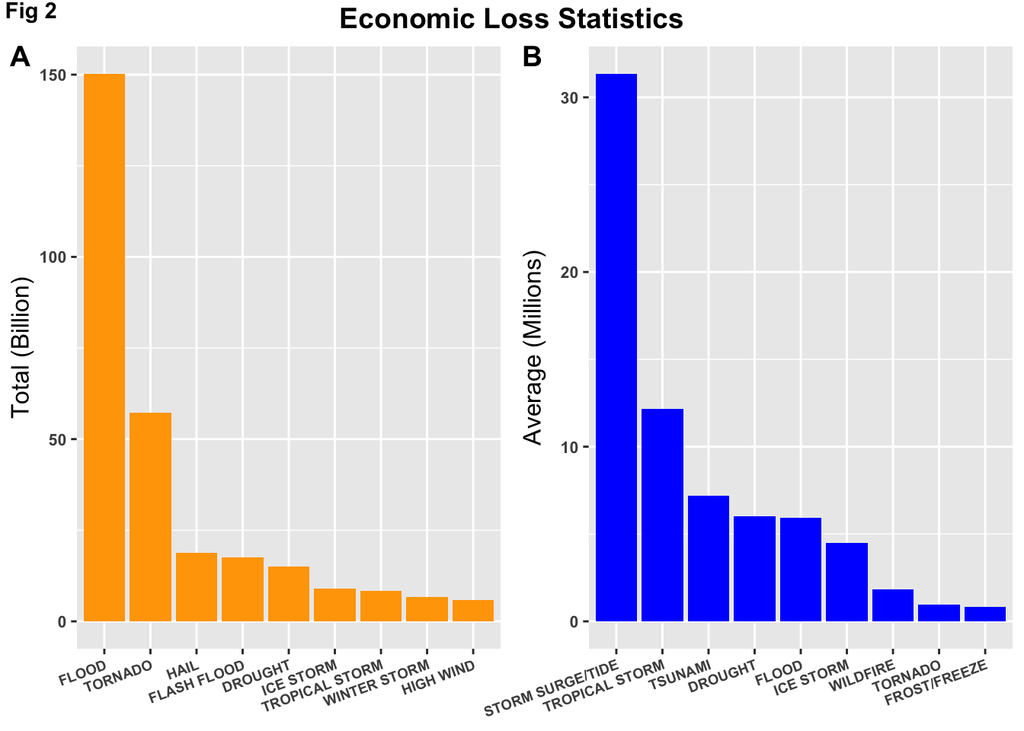

```r
# Plot A
p_seco <- filter(dt_tidy, sum_ecodmg>quan$sum_ecodmg) %>%
  mutate(EVTYPE = fct_reorder(EVTYPE, -sum_ecodmg)) %>%
  ggplot(aes(EVTYPE,sum_ecodmg/1000000000)) + geom_col(fill="orange") +
  theme(axis.text.x = element_text(angle = 20, hjust = 1, vjust = 1, size=7,face="bold"),
        axis.text.y = element_text(size=8,face="bold"),
        axis.title.y = element_text(size = 12)) +
  labs(x = NULL, y = "Total (Billion)")


# Plot B
p_meco <- filter(dt_tidy, mean_ecodmg>quan$mean_ecodmg) %>%
  mutate(EVTYPE = fct_reorder(EVTYPE, -mean_ecodmg)) %>%
  ggplot(aes(EVTYPE,mean_ecodmg/1000000)) + geom_col(fill="blue") +
  theme(axis.text.x = element_text(angle = 20, hjust = 1, vjust = 1, size=7,face="bold"),
        axis.text.y = element_text(size=8,face="bold"),
        axis.title.y = element_text(size = 12)) +
  labs(x = NULL, y = "Average (Millions)")


fg2 <- ggarrange(p_seco, p_meco,labels = c("A", "B"), ncol = 2, nrow =1, align="hv")
fg2 <- annotate_figure(fg2, top = text_grob("Economic Loss Statistics", face = "bold", size = 14), fig.lab = "Fig 2",fig.lab.face= "bold")
fg2
```

#### Discussion

**1. The flood caused the greatest total economic damage.**  
In terms of total data(Fig2 A), the flood caused the greatest total economic damage.  
**2. The storm surge/tide is the single most economically costly event type.**  
In terms of average data(Fig2 B), storm surge/tide showed its extreme destructive power in economic damage. In addition, tropical storm and tsunami also have considerable destructive power. Flood rank fifth in terms of destructive power.